# Take-Home Assessment 1

Create a new `Quarto` file and copy the following statement into your new file. Then sign your name (by typing it) to the statement. Note that, in this and all future quizzes and assignments, full credit will not be given unless the statement and signature are present.

**Statement of Integrity**: “All work presented is my own, and I have followed all rules for collaboration. If I used any AI on this assignment, I have clearly stated both (1) what my search prompt was and (2) what I used from the AI answer.””

**Collaboration Reminder**: You **may** work with other students **in the class** on the quiz, but you must list who you worked with at the top of your quiz. Write the name of any student(s) that you collaborated with in the space below this (ignore this if you did not collaborate with any students).

**Important**: Remember to change your header so that the rendered `.html` file is embed-resources.

```
---
title: "Your Title"
author: "Your Name"
format:
  html:
    embed-resources: true
---
```

A suggestion for completing this quiz is to make an attempt at it only looking at handwritten notes. The reason for this is that the questions are meant to mirror the style of the handwritten in-class quiz, and you will only have access to handwritten notes for that quiz.

**Question 1** (1 point). Consider the following graph:

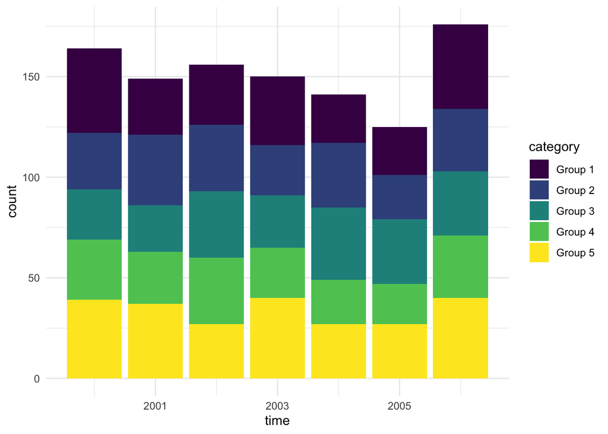

For which level of the `category` variable is it **easiest** to see the overall trend in the count through time? Use terminology from our course reading to give a one sentence reason for your selection.

**Question 2** (2 points).

1. (1 point). Suppose that we want to make a map of the United States, and colour each state by the percent change in Covid cases this week compared to last week. States with an increase would have a positive percent change while states with a decrease would have a negative percent change. Should we use a sequential, diverging, or qualitative colour scale to colour the states? Give a one phrase or one sentence explanation.
2. (1 point). Suppose that, in our map, we now want to colour the states by the number of covid cases per 100,000 people. Should we use a sequential, diverging, or unordered colour scale to colour the states? Give a one phrase or one sentence explanation.

**Question 3** (2 points). Suppose that, after grading this entire first course assessment for each student, I tell the class that the average for the first assessment was 85 out of 100 points.

1. If you had the data on each student’s assessment grade, what graph would be most appropriate to visualize this data?
2. What would the graph you selected in (a) tell you that you are not able to obtain from knowing the average? There are many additional things that a visualization would convey, and you should list as many as you can.

**Question 4** (3 points). Examine the following pairs of graphs on data on baseball players in the 2018 season. For each pair, state which of the 7 Grammar of Graphics parameters is different between the two graphs. Give a one phrase or one sentence reason for each selection.

1. **Pair 1**.

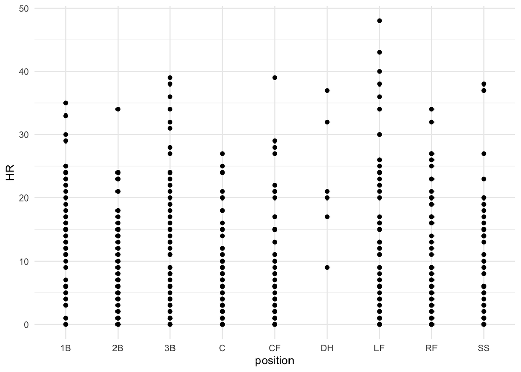

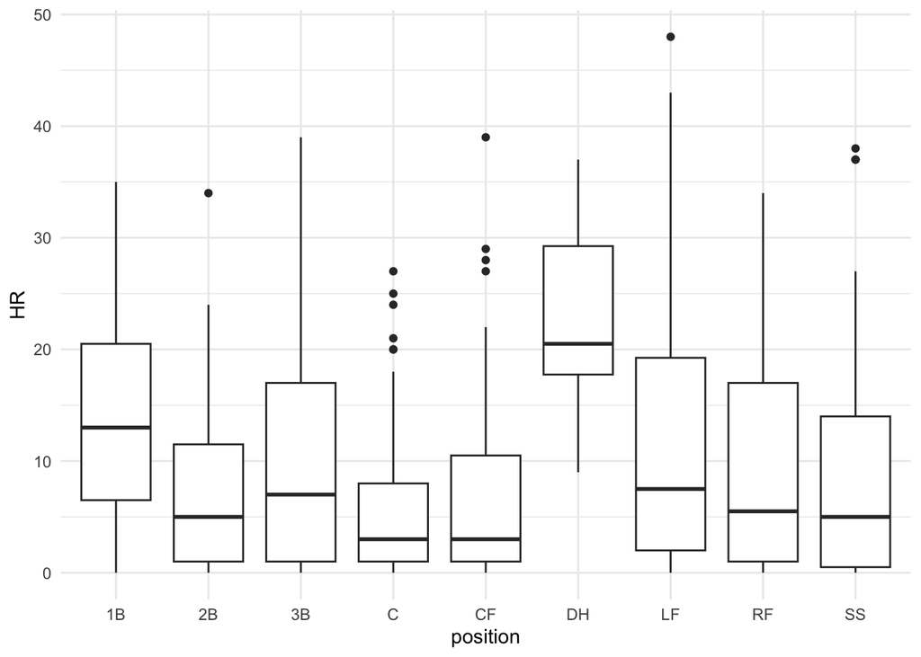

2. **Pair 2**. For the following pair, the `AESTHETICS` have not been adjusted at all.

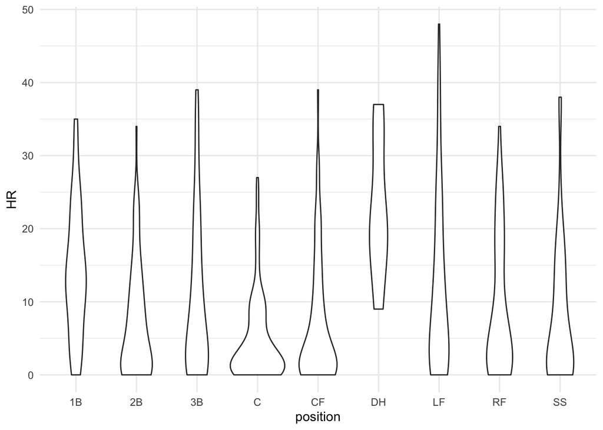

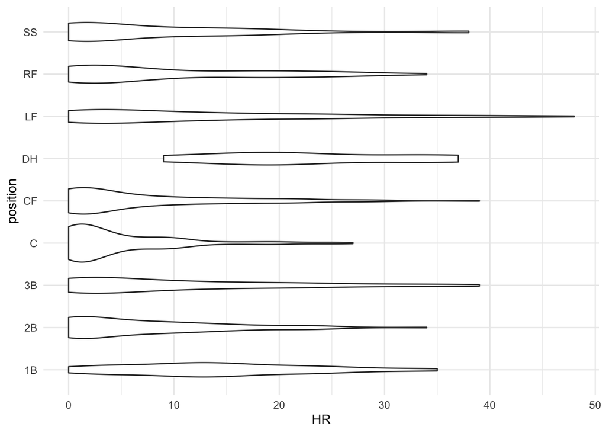

3. **Pair 3**. This pair shows the number of homeruns for each player (as points), along with boxplots of the number of homeruns at each of 4 positions.

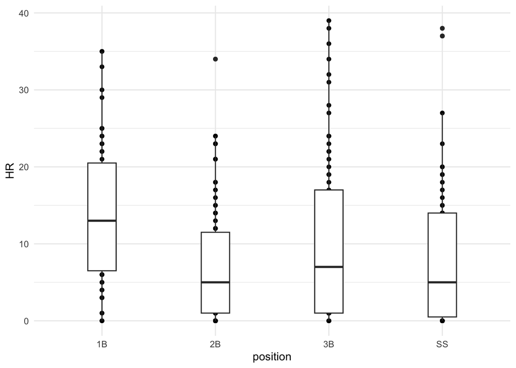

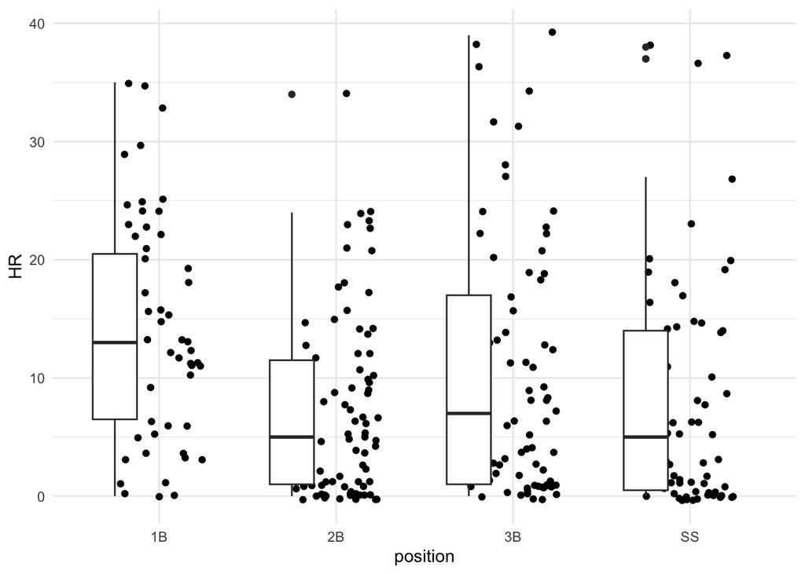

**Question 5** (2 points). Consider the following pairs of graphs. For each pair, select the graph that you believe is the better of the two. Give a 1-2 sentence reason for your selection, using reasoning from the course readings or from class.

1. The first pair examines the total number of players in the baseball data set in each of 4 positions.

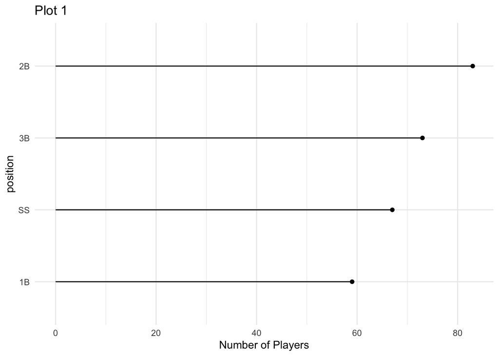

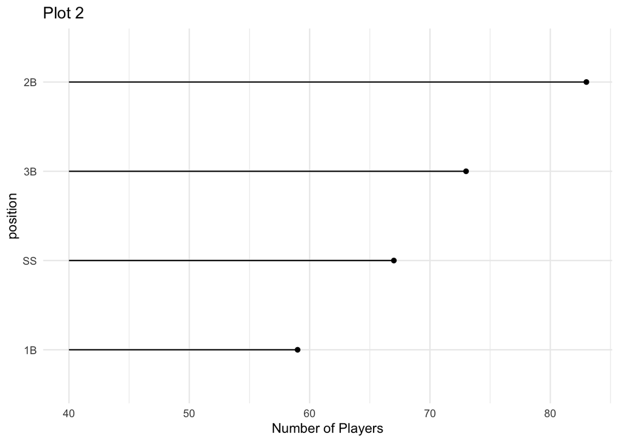

2. The second pair visualizes the number of homeruns for players in the data set, broken up by the player’s position.

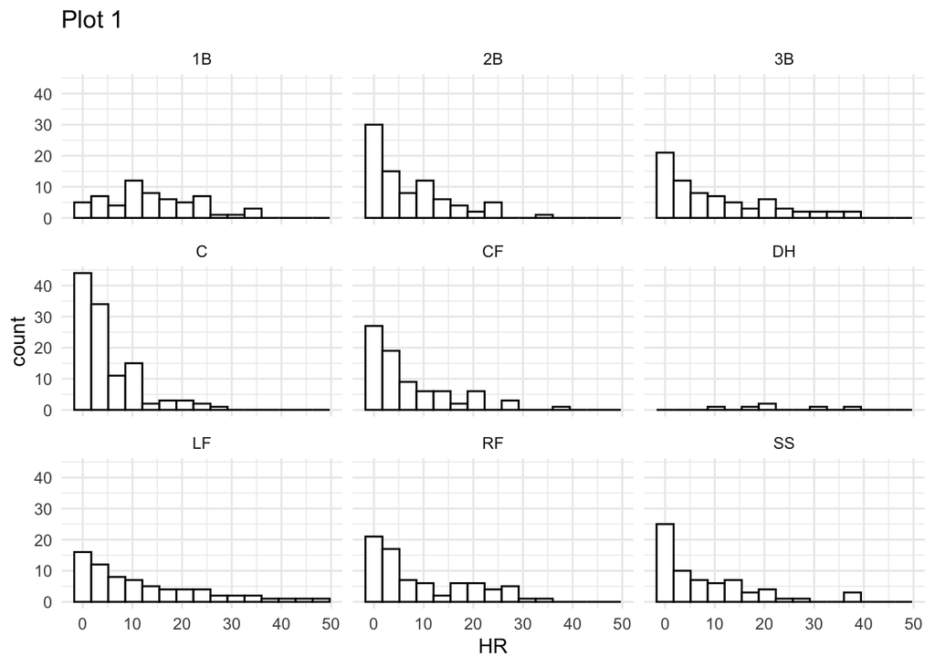

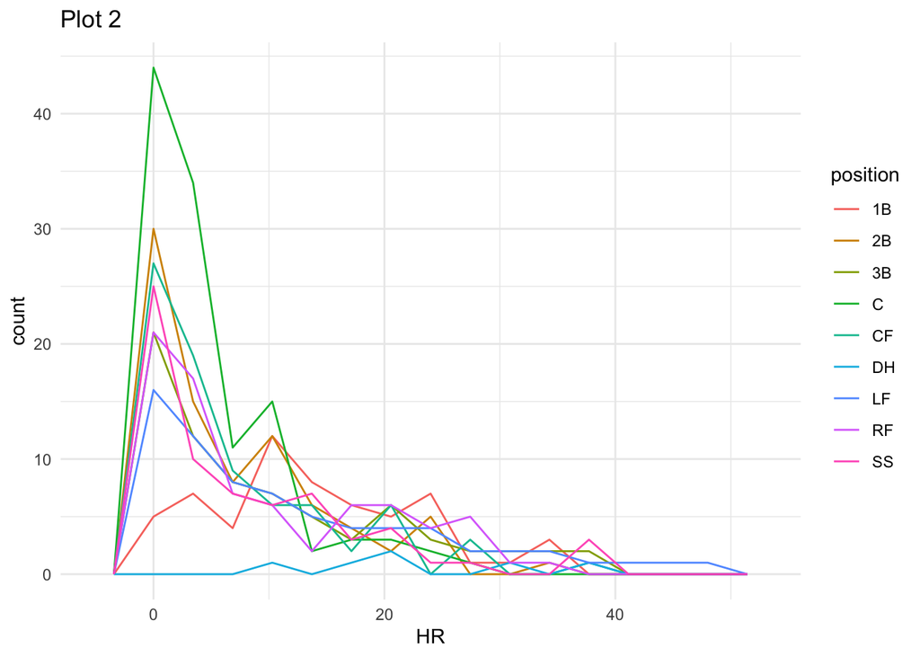